# Predict Bike Sharing Demand with AutoGluon Template

### Download and explore dataset

### Go to the bike sharing demand competition and agree to the terms

```python
# Download the dataset, it will be in a .zip file so you'll need to unzip it as well.
!kaggle competitions download -c bike-sharing-demand
# If you already downloaded it you can use the -o command to overwrite the file
!unzip -o bike-sharing-demand.zip
```

```
bike-sharing-demand.zip: Skipping, found more recently modified local copy (use --force to force download)
Archive:  bike-sharing-demand.zip
  inflating: sampleSubmission.csv
  inflating: test.csv
  inflating: train.csv
```

```python
import pandas as pd
from autogluon.tabular import TabularPredictor
```

```python
# Create the train dataset in pandas by reading the csv
# Set the parsing of the datetime column so you can use some of the `dt` features in pandas later

train = pd.read_csv('train.csv', parse_dates=['datetime'])

train.head()
```

|  | datetime | season | holiday | workingday | weather | temp | atemp | humidity | windspeed | casual | registered | count |
| --- | --- | --- | --- | --- | --- | --- | --- | --- | --- | --- | --- | --- |
| 0 | 2011-01-01 00:00:00 | 1 | 0 | 0 | 1 | 9.84 | 14.395 | 81 | 0.0 | 3 | 13 | 16 |
| 1 | 2011-01-01 01:00:00 | 1 | 0 | 0 | 1 | 9.02 | 13.635 | 80 | 0.0 | 8 | 32 | 40 |
| 2 | 2011-01-01 02:00:00 | 1 | 0 | 0 | 1 | 9.02 | 13.635 | 80 | 0.0 | 5 | 27 | 32 |
| 3 | 2011-01-01 03:00:00 | 1 | 0 | 0 | 1 | 9.84 | 14.395 | 75 | 0.0 | 3 | 10 | 13 |
| 4 | 2011-01-01 04:00:00 | 1 | 0 | 0 | 1 | 9.84 | 14.395 | 75 | 0.0 | 0 | 1 | 1 |

```python
type(train.loc[0, 'datetime'])
```

```
pandas._libs.tslibs.timestamps.Timestamp
```

```python
# Simple output of the train dataset to view some of the min/max/varition of the dataset features.
train.describe()
```

|  | season | holiday | workingday | weather | temp | atemp | humidity | windspeed | casual | registered | count |
| --- | --- | --- | --- | --- | --- | --- | --- | --- | --- | --- | --- |
| count | 10886.000000 | 10886.000000 | 10886.000000 | 10886.000000 | 10886.00000 | 10886.000000 | 10886.000000 | 10886.000000 | 10886.000000 | 10886.000000 | 10886.000000 |
| mean | 2.506614 | 0.028569 | 0.680875 | 1.418427 | 20.23086 | 23.655084 | 61.886460 | 12.799395 | 36.021955 | 155.552177 | 191.574132 |
| std | 1.116174 | 0.166599 | 0.466159 | 0.633839 | 7.79159 | 8.474601 | 19.245033 | 8.164537 | 49.960477 | 151.039033 | 181.144454 |
| min | 1.000000 | 0.000000 | 0.000000 | 1.000000 | 0.82000 | 0.760000 | 0.000000 | 0.000000 | 0.000000 | 0.000000 | 1.000000 |
| 25% | 2.000000 | 0.000000 | 0.000000 | 1.000000 | 13.94000 | 16.665000 | 47.000000 | 7.001500 | 4.000000 | 36.000000 | 42.000000 |
| 50% | 3.000000 | 0.000000 | 1.000000 | 1.000000 | 20.50000 | 24.240000 | 62.000000 | 12.998000 | 17.000000 | 118.000000 | 145.000000 |
| 75% | 4.000000 | 0.000000 | 1.000000 | 2.000000 | 26.24000 | 31.060000 | 77.000000 | 16.997900 | 49.000000 | 222.000000 | 284.000000 |
| max | 4.000000 | 1.000000 | 1.000000 | 4.000000 | 41.00000 | 45.455000 | 100.000000 | 56.996900 | 367.000000 | 886.000000 | 977.000000 |

```python
# Create the test pandas dataframe in pandas by reading the csv, remember to parse the datetime!
test = pd.read_csv('test.csv', parse_dates = ['datetime'])

test.head()
```

|  | datetime | season | holiday | workingday | weather | temp | atemp | humidity | windspeed |
| --- | --- | --- | --- | --- | --- | --- | --- | --- | --- |
| 0 | 2011-01-20 00:00:00 | 1 | 0 | 1 | 1 | 10.66 | 11.365 | 56 | 26.0027 |
| 1 | 2011-01-20 01:00:00 | 1 | 0 | 1 | 1 | 10.66 | 13.635 | 56 | 0.0000 |
| 2 | 2011-01-20 02:00:00 | 1 | 0 | 1 | 1 | 10.66 | 13.635 | 56 | 0.0000 |
| 3 | 2011-01-20 03:00:00 | 1 | 0 | 1 | 1 | 10.66 | 12.880 | 56 | 11.0014 |
| 4 | 2011-01-20 04:00:00 | 1 | 0 | 1 | 1 | 10.66 | 12.880 | 56 | 11.0014 |

```python
# Same thing as train and test dataset
submission = pd.read_csv('sampleSubmission.csv', parse_dates = ['datetime'])

submission.head()
```

|  | datetime | count |
| --- | --- | --- |
| 0 | 2011-01-20 00:00:00 | 0 |
| 1 | 2011-01-20 01:00:00 | 0 |
| 2 | 2011-01-20 02:00:00 | 0 |
| 3 | 2011-01-20 03:00:00 | 0 |
| 4 | 2011-01-20 04:00:00 | 0 |

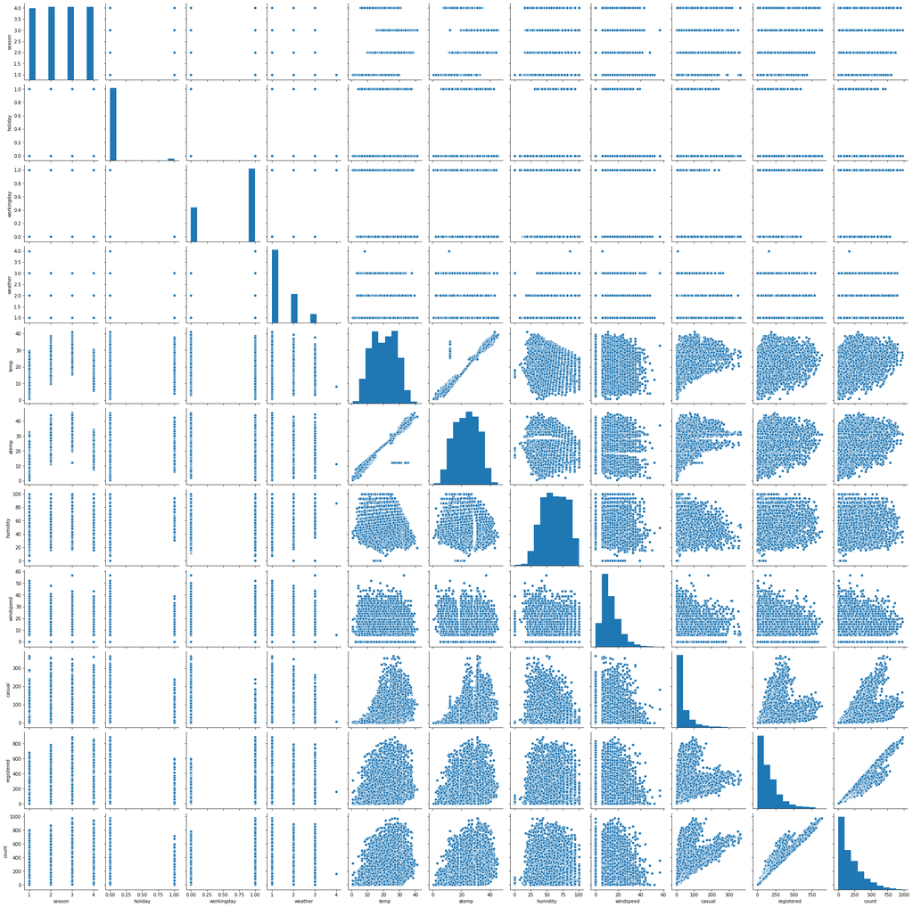

```python
#for graphical interpretation of relation between datset
import seaborn as sns
try:
    sns.pairplot(train)
except: pass
```

```python
#for checking NaN values in train dataset
sum(train.isna().values)
```

```
array([0, 0, 0, 0, 0, 0, 0, 0, 0, 0, 0, 0])
```

```python
#for checking Nan vlues in test dataset
sum(test.isna().values)
```

```
array([0, 0, 0, 0, 0, 0, 0, 0, 0])
```

## Step 3: Train a model using AutoGluon’s Tabular Prediction

Requirements:

- We are prediting `count`, so it is the label we are setting.
- Ignore `casual` and `registered` columns as they are also not present in the test dataset.
- Use the `root_mean_squared_error` as the metric to use for evaluation.
- Set a time limit of 10 minutes (600 seconds).
- Use the preset `best_quality` to focus on creating the best model.

```python
from autogluon.tabular import TabularDataset, TabularPredictor
```

```python
predictor = TabularPredictor(label="count",eval_metric="root_mean_squared_error", learner_kwargs={"ignored_columns": ["casual", "registered"]}).fit(
    train_data=train, time_limit=600, presets="best_quality")
```

```
No path specified. Models will be saved in: "AutogluonModels/ag-20220112_132859/"
Presets specified: ['best_quality']
Beginning AutoGluon training ... Time limit = 600s
AutoGluon will save models to "AutogluonModels/ag-20220112_132859/"
AutoGluon Version:  0.3.1
Train Data Rows:    10886
Train Data Columns: 11
Preprocessing data ...
AutoGluon infers your prediction problem is: 'regression' (because dtype of label-column == int and many unique label-values observed).
	Label info (max, min, mean, stddev): (977, 1, 191.57413, 181.14445)
	If 'regression' is not the correct problem_type, please manually specify the problem_type argument in fit() (You may specify problem_type as one of: ['binary', 'multiclass', 'regression'])
Using Feature Generators to preprocess the data ...
Dropping user-specified ignored columns: ['casual', 'registered']
Fitting AutoMLPipelineFeatureGenerator...
	Available Memory:                    2963.88 MB
	Train Data (Original)  Memory Usage: 0.78 MB (0.0% of available memory)
	Inferring data type of each feature based on column values. Set feature_metadata_in to manually specify special dtypes of the features.
	Stage 1 Generators:
		Fitting AsTypeFeatureGenerator...
			Note: Converting 2 features to boolean dtype as they only contain 2 unique values.
	Stage 2 Generators:
		Fitting FillNaFeatureGenerator...
	Stage 3 Generators:
		Fitting IdentityFeatureGenerator...
		Fitting DatetimeFeatureGenerator...
	Stage 4 Generators:
		Fitting DropUniqueFeatureGenerator...
	Types of features in original data (raw dtype, special dtypes):
		('datetime', []) : 1 | ['datetime']
		('float', [])    : 3 | ['temp', 'atemp', 'windspeed']
		('int', [])      : 5 | ['season', 'holiday', 'workingday', 'weather', 'humidity']
	Types of features in processed data (raw dtype, special dtypes):
		('float', [])                : 3 | ['temp', 'atemp', 'windspeed']
		('int', [])                  : 3 | ['season', 'weather', 'humidity']
		('int', ['bool'])            : 2 | ['holiday', 'workingday']
		('int', ['datetime_as_int']) : 1 | ['datetime']
	0.5s = Fit runtime
	9 features in original data used to generate 9 features in processed data.
	Train Data (Processed) Memory Usage: 0.63 MB (0.0% of available memory)
Data preprocessing and feature engineering runtime = 0.49s ...
AutoGluon will gauge predictive performance using evaluation metric: 'root_mean_squared_error'
	To change this, specify the eval_metric argument of fit()
AutoGluon will fit 2 stack levels (L1 to L2) ...
Fitting 11 L1 models ...
Fitting model: KNeighborsUnif_BAG_L1 ... Training model for up to 399.57s of the 599.5s of remaining time.
	-160.4131	 = Validation score   (root_mean_squared_error)
	0.03s	 = Training   runtime
	0.1s	 = Validation runtime
Fitting model: KNeighborsDist_BAG_L1 ... Training model for up to 399.16s of the 599.09s of remaining time.
	-169.5521	 = Validation score   (root_mean_squared_error)
	0.02s	 = Training   runtime
	0.1s	 = Validation runtime
Fitting model: LightGBMXT_BAG_L1 ... Training model for up to 398.74s of the 598.67s of remaining time.
```

```
[1000]	train_set's rmse: 123.806	valid_set's rmse: 134.369
[2000]	train_set's rmse: 117.412	valid_set's rmse: 133.705
```

```
[1000]	train_set's rmse: 123.42	valid_set's rmse: 141.5
```

```
[1000]	train_set's rmse: 125.097	valid_set's rmse: 128.797
[2000]	train_set's rmse: 119.003	valid_set's rmse: 127.909
[3000]	train_set's rmse: 114.63	valid_set's rmse: 127.431
[4000]	train_set's rmse: 111.295	valid_set's rmse: 126.943
[5000]	train_set's rmse: 108.576	valid_set's rmse: 126.844
[6000]	train_set's rmse: 106.085	valid_set's rmse: 126.71
```

```
[1000]	train_set's rmse: 124.131	valid_set's rmse: 138.303
[2000]	train_set's rmse: 117.833	valid_set's rmse: 137.535
```

```
[1000]	train_set's rmse: 124.871	valid_set's rmse: 128.052
[2000]	train_set's rmse: 118.547	valid_set's rmse: 127.003
[3000]	train_set's rmse: 114.124	valid_set's rmse: 126.834
[4000]	train_set's rmse: 110.645	valid_set's rmse: 126.694
```

```
[1000]	train_set's rmse: 124.654	valid_set's rmse: 135.095
[2000]	train_set's rmse: 118.764	valid_set's rmse: 133.849
[3000]	train_set's rmse: 114.615	valid_set's rmse: 133.509
[4000]	train_set's rmse: 111.249	valid_set's rmse: 133.472
[5000]	train_set's rmse: 108.455	valid_set's rmse: 133.281
```

```
[1000]	train_set's rmse: 124.01	valid_set's rmse: 139.355
[2000]	train_set's rmse: 117.819	valid_set's rmse: 138.312
[3000]	train_set's rmse: 113.4	valid_set's rmse: 137.886
[4000]	train_set's rmse: 110.032	valid_set's rmse: 137.758
```

```
[1000]	train_set's rmse: 124.47	valid_set's rmse: 135.412
```

```
[1000]	train_set's rmse: 124.18	valid_set's rmse: 137.579
[2000]	train_set's rmse: 117.782	valid_set's rmse: 136.664
[3000]	train_set's rmse: 113.447	valid_set's rmse: 136.246
[4000]	train_set's rmse: 109.982	valid_set's rmse: 136.227
```

```
[1000]	train_set's rmse: 124.641	valid_set's rmse: 132.484
```

```
	-134.0883	 = Validation score   (root_mean_squared_error)
	38.18s	 = Training   runtime
	2.26s	 = Validation runtime
Fitting model: LightGBM_BAG_L1 ... Training model for up to 351.53s of the 551.46s of remaining time.
```

```
[1000]	train_set's rmse: 96.0217	valid_set's rmse: 123.249
```

```
[1000]	train_set's rmse: 94.7479	valid_set's rmse: 135.635
```

```
[1000]	train_set's rmse: 95.3055	valid_set's rmse: 132.087
```

```
[1000]	train_set's rmse: 95.1635	valid_set's rmse: 131.521
```

```
/opt/conda/lib/python3.7/site-packages/lightgbm/engine.py:239: UserWarning: 'verbose_eval' argument is deprecated and will be removed in a future release of LightGBM. Pass 'log_evaluation()' callback via 'callbacks' argument instead.
  _log_warning("'verbose_eval' argument is deprecated and will be removed in a future release of LightGBM. "
/opt/conda/lib/python3.7/site-packages/lightgbm/engine.py:239: UserWarning: 'verbose_eval' argument is deprecated and will be removed in a future release of LightGBM. Pass 'log_evaluation()' callback via 'callbacks' argument instead.
  _log_warning("'verbose_eval' argument is deprecated and will be removed in a future release of LightGBM. "
	-132.2864	 = Validation score   (root_mean_squared_error)
	10.91s	 = Training   runtime
	0.46s	 = Validation runtime
Fitting model: RandomForestMSE_BAG_L1 ... Training model for up to 338.11s of the 538.05s of remaining time.
	-118.4567	 = Validation score   (root_mean_squared_error)
	6.95s	 = Training   runtime
	0.37s	 = Validation runtime
Fitting model: CatBoost_BAG_L1 ... Training model for up to 328.27s of the 528.21s of remaining time.
	-132.3497	 = Validation score   (root_mean_squared_error)
	59.57s	 = Training   runtime
	0.04s	 = Validation runtime
Fitting model: ExtraTreesMSE_BAG_L1 ... Training model for up to 267.91s of the 467.84s of remaining time.
	-128.7334	 = Validation score   (root_mean_squared_error)
	3.01s	 = Training   runtime
	0.37s	 = Validation runtime
Fitting model: NeuralNetFastAI_BAG_L1 ... Training model for up to 262.07s of the 462.0s of remaining time.
	-138.082	 = Validation score   (root_mean_squared_error)
	93.16s	 = Training   runtime
	0.24s	 = Validation runtime
Fitting model: XGBoost_BAG_L1 ... Training model for up to 167.95s of the 367.88s of remaining time.
	-132.3085	 = Validation score   (root_mean_squared_error)
	15.82s	 = Training   runtime
	0.14s	 = Validation runtime
Fitting model: NeuralNetMXNet_BAG_L1 ... Training model for up to 150.17s of the 350.1s of remaining time.
	Ran out of time, stopping training early. (Stopping on epoch 15)
	Ran out of time, stopping training early. (Stopping on epoch 18)
	Ran out of time, stopping training early. (Stopping on epoch 18)
	Ran out of time, stopping training early. (Stopping on epoch 19)
	Ran out of time, stopping training early. (Stopping on epoch 19)
	Ran out of time, stopping training early. (Stopping on epoch 20)
	Ran out of time, stopping training early. (Stopping on epoch 22)
	Ran out of time, stopping training early. (Stopping on epoch 23)
	Ran out of time, stopping training early. (Stopping on epoch 25)
	Ran out of time, stopping training early. (Stopping on epoch 31)
	-143.0114	 = Validation score   (root_mean_squared_error)
	142.95s	 = Training   runtime
```

[output cut: 86 more lines]

```
Fitting model: NeuralNetMXNet_BAG_L2 ... Training model for up to 3.42s of the 3.38s of remaining time.
	Time limit exceeded... Skipping NeuralNetMXNet_BAG_L2.
Fitting model: LightGBMLarge_BAG_L2 ... Training model for up to 2.95s of the 2.91s of remaining time.
/opt/conda/lib/python3.7/site-packages/lightgbm/engine.py:239: UserWarning: 'verbose_eval' argument is deprecated and will be removed in a future release of LightGBM. Pass 'log_evaluation()' callback via 'callbacks' argument instead.
  _log_warning("'verbose_eval' argument is deprecated and will be removed in a future release of LightGBM. "
	Ran out of time, early stopping on iteration 12. Best iteration is:
	[12]	train_set's rmse: 146.974	valid_set's rmse: 146.249
	Time limit exceeded... Skipping LightGBMLarge_BAG_L2.
Completed 1/20 k-fold bagging repeats ...
Fitting model: WeightedEnsemble_L3 ... Training model for up to 360.0s of the 2.44s of remaining time.
	-115.0131	 = Validation score   (root_mean_squared_error)
	0.27s	 = Training   runtime
	0.0s	 = Validation runtime
AutoGluon training complete, total runtime = 598.07s ...
TabularPredictor saved. To load, use: predictor = TabularPredictor.load("AutogluonModels/ag-20220112_132859/")
```

### Review AutoGluon's training run with ranking of models that did the best.

```python
predictor.fit_summary()
```

```
*** Summary of fit() ***
Estimated performance of each model:
                     model   score_val  pred_time_val    fit_time  pred_time_val_marginal  fit_time_marginal  stack_level  can_infer  fit_order
0      WeightedEnsemble_L3 -115.013138       6.700870  487.468833                0.000549           0.267313            3       True         19
1   NeuralNetFastAI_BAG_L2 -115.491003       5.858425  465.102772                0.286790          94.509806            2       True         17
2        LightGBMXT_BAG_L2 -116.429556       5.875568  380.011685                0.303933           9.418719            2       True         12
3          CatBoost_BAG_L2 -116.586650       5.603563  398.285023                0.031928          27.692057            2       True         15
4          LightGBM_BAG_L2 -117.005587       5.660889  376.958277                0.089254           6.365311            2       True         13
5           XGBoost_BAG_L2 -117.648275       5.652711  386.392321                0.081076          15.799355            2       True         18
6     ExtraTreesMSE_BAG_L2 -117.660256       6.020345  376.907684                0.448710           6.314718            2       True         16
7      WeightedEnsemble_L2 -118.438484       1.844033  150.253586                0.000545           0.350665            2       True         11
8   RandomForestMSE_BAG_L1 -118.456660       0.371176    6.948568                0.371176           6.948568            1       True          5
9   RandomForestMSE_BAG_L2 -119.433357       6.032071  400.347506                0.460436          29.754540            2       True         14
10    ExtraTreesMSE_BAG_L1 -128.733445       0.373152    3.006630                0.373152           3.006630            1       True          7
11         LightGBM_BAG_L1 -132.286410       0.460892   10.907528                0.460892          10.907528            1       True          4
12          XGBoost_BAG_L1 -132.308522       0.136395   15.823461                0.136395          15.823461            1       True          9
13         CatBoost_BAG_L1 -132.349692       0.043813   59.566333                0.043813          59.566333            1       True          6
14       LightGBMXT_BAG_L1 -134.088334       2.264844   38.177064                2.264844          38.177064            1       True          3
15  NeuralNetFastAI_BAG_L1 -138.081951       0.242147   93.156085                0.242147          93.156085            1       True          8
16   NeuralNetMXNet_BAG_L1 -143.011432       1.472311  142.954353                1.472311         142.954353            1       True         10
17   KNeighborsUnif_BAG_L1 -160.413078       0.102996    0.032236                0.102996           0.032236            1       True          1
18   KNeighborsDist_BAG_L1 -169.552096       0.103909    0.020709                0.103909           0.020709            1       True          2
Number of models trained: 19
Types of models trained:
{'StackerEnsembleModel_RF', 'StackerEnsembleModel_CatBoost', 'StackerEnsembleModel_XT', 'WeightedEnsembleModel', 'StackerEnsembleModel_KNN', 'StackerEnsembleModel_NNFastAiTabular', 'StackerEnsembleModel_XGBoost', 'StackerEnsembleModel_LGB', 'StackerEnsembleModel_TabularNeuralNet'}
Bagging used: True  (with 10 folds)
Multi-layer stack-ensembling used: True  (with 3 levels)
Feature Metadata (Processed):
(raw dtype, special dtypes):
('float', [])                : 3 | ['temp', 'atemp', 'windspeed']
('int', [])                  : 3 | ['season', 'weather', 'humidity']
('int', ['bool'])            : 2 | ['holiday', 'workingday']
('int', ['datetime_as_int']) : 1 | ['datetime']
Plot summary of models saved to file: AutogluonModels/ag-20220112_132859/SummaryOfModels.html
*** End of fit() summary ***
```

```
{'model_types': {'KNeighborsUnif_BAG_L1': 'StackerEnsembleModel_KNN',
  'KNeighborsDist_BAG_L1': 'StackerEnsembleModel_KNN',
  'LightGBMXT_BAG_L1': 'StackerEnsembleModel_LGB',
  'LightGBM_BAG_L1': 'StackerEnsembleModel_LGB',
  'RandomForestMSE_BAG_L1': 'StackerEnsembleModel_RF',
  'CatBoost_BAG_L1': 'StackerEnsembleModel_CatBoost',
  'ExtraTreesMSE_BAG_L1': 'StackerEnsembleModel_XT',
  'NeuralNetFastAI_BAG_L1': 'StackerEnsembleModel_NNFastAiTabular',
  'XGBoost_BAG_L1': 'StackerEnsembleModel_XGBoost',
  'NeuralNetMXNet_BAG_L1': 'StackerEnsembleModel_TabularNeuralNet',
  'WeightedEnsemble_L2': 'WeightedEnsembleModel',
  'LightGBMXT_BAG_L2': 'StackerEnsembleModel_LGB',
  'LightGBM_BAG_L2': 'StackerEnsembleModel_LGB',
  'RandomForestMSE_BAG_L2': 'StackerEnsembleModel_RF',
  'CatBoost_BAG_L2': 'StackerEnsembleModel_CatBoost',
  'ExtraTreesMSE_BAG_L2': 'StackerEnsembleModel_XT',
  'NeuralNetFastAI_BAG_L2': 'StackerEnsembleModel_NNFastAiTabular',
  'XGBoost_BAG_L2': 'StackerEnsembleModel_XGBoost',
  'WeightedEnsemble_L3': 'WeightedEnsembleModel'},
 'model_performance': {'KNeighborsUnif_BAG_L1': -160.41307794634753,
  'KNeighborsDist_BAG_L1': -169.55209635208976,
  'LightGBMXT_BAG_L1': -134.08833420116997,
  'LightGBM_BAG_L1': -132.28640961443512,
  'RandomForestMSE_BAG_L1': -118.45666016795751,
  'CatBoost_BAG_L1': -132.3496915713461,
  'ExtraTreesMSE_BAG_L1': -128.73344506216944,
  'NeuralNetFastAI_BAG_L1': -138.0819510363203,
  'XGBoost_BAG_L1': -132.30852184526844,
  'NeuralNetMXNet_BAG_L1': -143.01143196618926,
  'WeightedEnsemble_L2': -118.43848379694963,
  'LightGBMXT_BAG_L2': -116.42955597496538,
  'LightGBM_BAG_L2': -117.00558694069697,
  'RandomForestMSE_BAG_L2': -119.43335677419154,
  'CatBoost_BAG_L2': -116.58664992368467,
  'ExtraTreesMSE_BAG_L2': -117.66025634363993,
  'NeuralNetFastAI_BAG_L2': -115.4910030497183,
  'XGBoost_BAG_L2': -117.64827547057918,
  'WeightedEnsemble_L3': -115.0131382384555},
 'model_best': 'WeightedEnsemble_L3',
 'model_paths': {'KNeighborsUnif_BAG_L1': 'AutogluonModels/ag-20220112_132859/models/KNeighborsUnif_BAG_L1/',
```

[output cut: 187 more lines]

```
 4          13
 5          18
 6          16
 7          11
 8           5
 9          14
 10          7
 11          4
 12          9
 13          6
 14          3
 15          8
 16         10
 17          1
 18          2  }
```

### Create predictions from test dataset

```python
predictions = predictor.predict(test)
```

```python
predictions.head()
```

```
0     96.875526
1     88.470695
2     88.471687
3    106.010887
4    105.953094
Name: count, dtype: float32
```

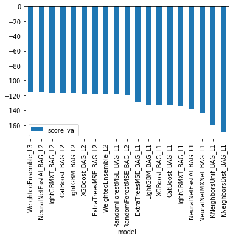

```python
predictor.leaderboard(silent=True).plot(kind='bar', x='model', y='score_val')
```

#### NOTE: Kaggle will reject the submission if we don't set everything to be > 0.

```python
# Describe the `predictions` series to see if there are any negative values
predictions.describe()
```

```
count    6493.000000
mean      211.815475
std       128.541107
min        -6.660267
25%       107.021172
50%       194.665314
75%       297.321777
max       657.261841
Name: count, dtype: float64
```

```python
# How many negative values do we have?
#predictions.count([predictions['count'] < 0 )
```

[output not shown]

```python
# Set them to zero
predictions[predictions<0]=0
```

### Set predictions to submission dataframe, save, and submit

```python
submission["count"] = predictions
submission.to_csv("submission.csv", index=False)
```

```python
!kaggle competitions submit -c bike-sharing-demand -f submission.csv -m "first raw submission"
```

```
Successfully submitted to Bike Sharing Demand
```

#### View submission via the command line or in the web browser under the competition's page - `My Submissions`

```python
!kaggle competitions submissions -c bike-sharing-demand | tail -n +1 | head -n 6
```

```
fileName                     date                 description                        status    publicScore  privateScore
---------------------------  -------------------  ---------------------------------  --------  -----------  ------------
submission.csv               2022-01-12 14:06:20  first raw submission               complete  1.39644      1.39644
submission_new_hpo.csv       2022-01-11 18:12:01  new features with hyperparameters  complete  0.51059      0.51059
submission_new_hpo.csv       2022-01-11 17:57:23  new features with hyperparameters  complete  0.50611      0.50611
submission_new_features.csv  2022-01-11 16:42:24  new features                       complete  0.48265      0.48265
```

## Step 4: Exploratory Data Analysis and Creating an additional feature

- Any additional feature will do, but a great suggestion would be to separate out the datetime into hour, day, or month parts.

```
array([[<matplotlib.axes._subplots.AxesSubplot object at 0x7fef6dda3250>,
      dtype=object)
```

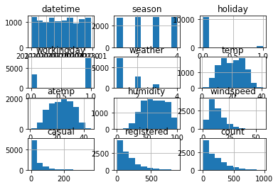

```python
# Create a histogram of all features to show the distribution of each one relative to the data. This is part of the exploritory data analysis
train.hist()
```

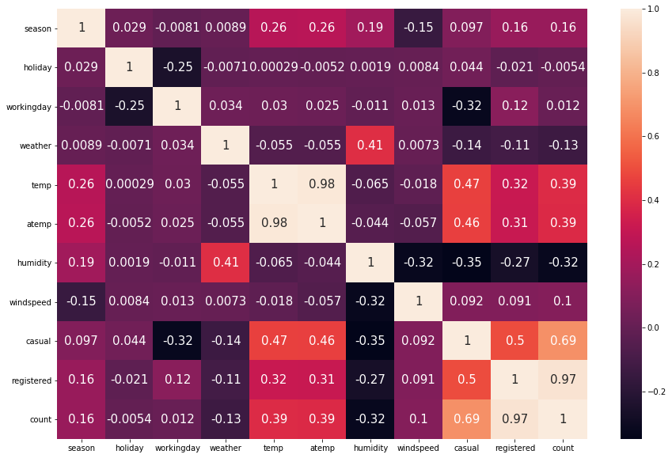

```python
import matplotlib.pyplot as plt
corr = train.corr()
plt.figure(figsize=(15,10))
sns.heatmap(corr, annot=True, annot_kws = {'size':15})
```

```
[Text(0.5, 1.0, 'Relationbetween weather and users')]
```

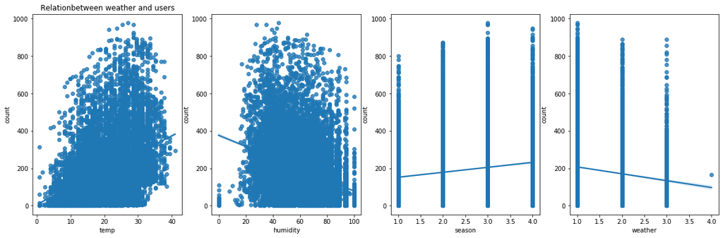

```python
fig, (ax1,ax2,ax3,ax4) = plt.subplots(ncols = 4 , figsize = (20,6))
sns.regplot(x=train['temp'],y = train['count'],ax=ax1)
ax1.set(title="Relation between temperature and users")
sns.regplot(x=train['humidity'],y = train['count'],ax=ax2)
ax1.set(title="Relation between humidity and users")
sns.regplot(x=train['season'],y = train['count'],ax=ax3)
ax1.set(title="Relationbetween season and users")
sns.regplot(x=train['weather'],y = train['count'],ax=ax4)
ax1.set(title="Relationbetween weather and users")
```

```python
# create a new feature
train['hour'] = train['datetime'].dt.hour
train['day'] = train['datetime'].dt.day
train['month'] = train['datetime'].dt.month


test['hour'] = test['datetime'].dt.hour
test['day'] = test['datetime'].dt.day
test['month'] = test['datetime'].dt.month
```

## Make category types for these so models know they are not just numbers

- AutoGluon originally sees these as ints, but in reality they are int representations of a category.
- Setting the dtype to category will classify these as categories in AutoGluon.

```python
train["season"] = train["season"].astype('category')
train["weather"] = train["weather"].astype('category')
train["holiday"] = train["holiday"].astype('category')

test["season"] = test["season"].astype('category')
test["weather"] = test["weather"].astype('category')
test["holiday"] = test["holiday"].astype('category')
```

```python
# View are new feature
train.head()
```

|  | datetime | season | holiday | workingday | weather | temp | atemp | humidity | windspeed | casual | registered | count | hour | day | month |
| --- | --- | --- | --- | --- | --- | --- | --- | --- | --- | --- | --- | --- | --- | --- | --- |
| 0 | 2011-01-01 00:00:00 | 1 | 0 | 0 | 1 | 9.84 | 14.395 | 81 | 0.0 | 3 | 13 | 16 | 0 | 1 | 1 |
| 1 | 2011-01-01 01:00:00 | 1 | 0 | 0 | 1 | 9.02 | 13.635 | 80 | 0.0 | 8 | 32 | 40 | 1 | 1 | 1 |
| 2 | 2011-01-01 02:00:00 | 1 | 0 | 0 | 1 | 9.02 | 13.635 | 80 | 0.0 | 5 | 27 | 32 | 2 | 1 | 1 |
| 3 | 2011-01-01 03:00:00 | 1 | 0 | 0 | 1 | 9.84 | 14.395 | 75 | 0.0 | 3 | 10 | 13 | 3 | 1 | 1 |
| 4 | 2011-01-01 04:00:00 | 1 | 0 | 0 | 1 | 9.84 | 14.395 | 75 | 0.0 | 0 | 1 | 1 | 4 | 1 | 1 |

```
array([[<matplotlib.axes._subplots.AxesSubplot object at 0x7fef5a9e7c50>,
      dtype=object)
```

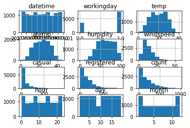

```python
# View histogram of all features again now with the hour feature
train.hist()
```

## Step 5: Rerun the model with the same settings as before, just with more features

```python
predictor_new_features = TabularPredictor(label="count",eval_metric="root_mean_squared_error", learner_kwargs={"ignored_columns": ["casual", "registered"]}).fit(
    train_data=train, time_limit=600, presets="best_quality")
```

```
No path specified. Models will be saved in: "AutogluonModels/ag-20220112_145311/"
Presets specified: ['best_quality']
Beginning AutoGluon training ... Time limit = 600s
AutoGluon will save models to "AutogluonModels/ag-20220112_145311/"
AutoGluon Version:  0.3.1
Train Data Rows:    10886
Train Data Columns: 14
Preprocessing data ...
AutoGluon infers your prediction problem is: 'regression' (because dtype of label-column == int and many unique label-values observed).
	Label info (max, min, mean, stddev): (977, 1, 191.57413, 181.14445)
	If 'regression' is not the correct problem_type, please manually specify the problem_type argument in fit() (You may specify problem_type as one of: ['binary', 'multiclass', 'regression'])
Using Feature Generators to preprocess the data ...
Dropping user-specified ignored columns: ['casual', 'registered']
Fitting AutoMLPipelineFeatureGenerator...
	Available Memory:                    2055.78 MB
	Train Data (Original)  Memory Usage: 0.82 MB (0.0% of available memory)
	Inferring data type of each feature based on column values. Set feature_metadata_in to manually specify special dtypes of the features.
	Stage 1 Generators:
		Fitting AsTypeFeatureGenerator...
			Note: Converting 2 features to boolean dtype as they only contain 2 unique values.
	Stage 2 Generators:
		Fitting FillNaFeatureGenerator...
	Stage 3 Generators:
		Fitting IdentityFeatureGenerator...
		Fitting CategoryFeatureGenerator...
			Fitting CategoryMemoryMinimizeFeatureGenerator...
		Fitting DatetimeFeatureGenerator...
	Stage 4 Generators:
		Fitting DropUniqueFeatureGenerator...
	Types of features in original data (raw dtype, special dtypes):
		('category', []) : 3 | ['season', 'holiday', 'weather']
		('datetime', []) : 1 | ['datetime']
		('float', [])    : 3 | ['temp', 'atemp', 'windspeed']
		('int', [])      : 5 | ['workingday', 'humidity', 'hour', 'day', 'month']
	Types of features in processed data (raw dtype, special dtypes):
		('category', [])             : 2 | ['season', 'weather']
		('float', [])                : 3 | ['temp', 'atemp', 'windspeed']
		('int', [])                  : 4 | ['humidity', 'hour', 'day', 'month']
		('int', ['bool'])            : 2 | ['holiday', 'workingday']
		('int', ['datetime_as_int']) : 1 | ['datetime']
	0.1s = Fit runtime
	12 features in original data used to generate 12 features in processed data.
	Train Data (Processed) Memory Usage: 0.74 MB (0.0% of available memory)
Data preprocessing and feature engineering runtime = 0.14s ...
AutoGluon will gauge predictive performance using evaluation metric: 'root_mean_squared_error'
	To change this, specify the eval_metric argument of fit()
AutoGluon will fit 2 stack levels (L1 to L2) ...
Fitting 11 L1 models ...
Fitting model: KNeighborsUnif_BAG_L1 ... Training model for up to 399.81s of the 599.86s of remaining time.
	-123.9226	 = Validation score   (root_mean_squared_error)
	0.03s	 = Training   runtime
	0.2s	 = Validation runtime
Fitting model: KNeighborsDist_BAG_L1 ... Training model for up to 399.31s of the 599.36s of remaining time.
	-119.3734	 = Validation score   (root_mean_squared_error)
	0.02s	 = Training   runtime
	0.2s	 = Validation runtime
Fitting model: LightGBMXT_BAG_L1 ... Training model for up to 398.81s of the 598.86s of remaining time.
```

```
[1000]	train_set's rmse: 30.4157	valid_set's rmse: 37.511
[2000]	train_set's rmse: 25.727	valid_set's rmse: 35.8802
[3000]	train_set's rmse: 23.0403	valid_set's rmse: 35.4125
[4000]	train_set's rmse: 21.1098	valid_set's rmse: 35.3735
[5000]	train_set's rmse: 19.6113	valid_set's rmse: 35.357
```

```
[1000]	train_set's rmse: 30.5133	valid_set's rmse: 41.9233
[2000]	train_set's rmse: 25.8593	valid_set's rmse: 39.6286
[3000]	train_set's rmse: 23.1659	valid_set's rmse: 38.8863
[4000]	train_set's rmse: 21.2723	valid_set's rmse: 38.516
[5000]	train_set's rmse: 19.7688	valid_set's rmse: 38.2756
[6000]	train_set's rmse: 18.5105	valid_set's rmse: 38.1661
[7000]	train_set's rmse: 17.4755	valid_set's rmse: 38.0968
[8000]	train_set's rmse: 16.5498	valid_set's rmse: 38.0203
[9000]	train_set's rmse: 15.7383	valid_set's rmse: 37.9545
[10000]	train_set's rmse: 14.9841	valid_set's rmse: 37.9045
```

```
[1000]	train_set's rmse: 30.906	valid_set's rmse: 35.1033
[2000]	train_set's rmse: 26.1475	valid_set's rmse: 34.1491
[3000]	train_set's rmse: 23.4094	valid_set's rmse: 34.1025
```

```
[1000]	train_set's rmse: 30.3445	valid_set's rmse: 40.5408
[2000]	train_set's rmse: 25.639	valid_set's rmse: 39.1298
[3000]	train_set's rmse: 23.0931	valid_set's rmse: 38.7256
[4000]	train_set's rmse: 21.2506	valid_set's rmse: 38.422
[5000]	train_set's rmse: 19.7564	valid_set's rmse: 38.2183
[6000]	train_set's rmse: 18.5126	valid_set's rmse: 38.0486
[7000]	train_set's rmse: 17.4664	valid_set's rmse: 37.9144
[8000]	train_set's rmse: 16.5767	valid_set's rmse: 37.854
[9000]	train_set's rmse: 15.7714	valid_set's rmse: 37.8438
[10000]	train_set's rmse: 15.0355	valid_set's rmse: 37.7983
```

```
[1000]	train_set's rmse: 30.6181	valid_set's rmse: 38.5536
[2000]	train_set's rmse: 25.875	valid_set's rmse: 37.1919
[3000]	train_set's rmse: 23.143	valid_set's rmse: 37.0082
```

```
[1000]	train_set's rmse: 30.5318	valid_set's rmse: 41.2095
[2000]	train_set's rmse: 25.7422	valid_set's rmse: 40.2816
[3000]	train_set's rmse: 23.0411	valid_set's rmse: 40.1033
[4000]	train_set's rmse: 21.1256	valid_set's rmse: 40.0478
```

```
[1000]	train_set's rmse: 31.0195	valid_set's rmse: 38.6581
[2000]	train_set's rmse: 26.2305	valid_set's rmse: 35.729
[3000]	train_set's rmse: 23.5288	valid_set's rmse: 34.8288
[4000]	train_set's rmse: 21.5716	valid_set's rmse: 34.5206
[5000]	train_set's rmse: 19.9611	valid_set's rmse: 34.3336
[6000]	train_set's rmse: 18.6552	valid_set's rmse: 34.2076
[7000]	train_set's rmse: 17.5717	valid_set's rmse: 34.1955
[8000]	train_set's rmse: 16.6293	valid_set's rmse: 34.1921
```

```
[1000]	train_set's rmse: 30.544	valid_set's rmse: 38.5247
[2000]	train_set's rmse: 25.7696	valid_set's rmse: 37.29
[3000]	train_set's rmse: 23.1454	valid_set's rmse: 36.923
[4000]	train_set's rmse: 21.2462	valid_set's rmse: 36.8032
[5000]	train_set's rmse: 19.7749	valid_set's rmse: 36.6545
[6000]	train_set's rmse: 18.5662	valid_set's rmse: 36.6581
[7000]	train_set's rmse: 17.5139	valid_set's rmse: 36.6594
[8000]	train_set's rmse: 16.5797	valid_set's rmse: 36.6603
```

```
[1000]	train_set's rmse: 30.3459	valid_set's rmse: 40.4898
[2000]	train_set's rmse: 25.5257	valid_set's rmse: 39.5682
[3000]	train_set's rmse: 22.8797	valid_set's rmse: 39.3154
```

```
[1000]	train_set's rmse: 31.0869	valid_set's rmse: 37.2751
[2000]	train_set's rmse: 26.157	valid_set's rmse: 35.2044
[3000]	train_set's rmse: 23.4751	valid_set's rmse: 34.5605
[4000]	train_set's rmse: 21.5298	valid_set's rmse: 34.347
[5000]	train_set's rmse: 19.9674	valid_set's rmse: 34.153
[6000]	train_set's rmse: 18.7136	valid_set's rmse: 34.1335
```

```
	-36.6734	 = Validation score   (root_mean_squared_error)
	91.07s	 = Training   runtime
	4.89s	 = Validation runtime
Fitting model: LightGBM_BAG_L1 ... Training model for up to 290.91s of the 490.96s of remaining time.
```

```
[1000]	train_set's rmse: 21.1363	valid_set's rmse: 35.5572
[2000]	train_set's rmse: 15.5114	valid_set's rmse: 35.4473
```

```
[1000]	train_set's rmse: 21.0431	valid_set's rmse: 36.9373
[2000]	train_set's rmse: 15.5393	valid_set's rmse: 36.1172
[3000]	train_set's rmse: 12.204	valid_set's rmse: 35.9179
[4000]	train_set's rmse: 9.99922	valid_set's rmse: 35.8485
```

```
[1000]	train_set's rmse: 21.4766	valid_set's rmse: 32.789
```

```
[1000]	train_set's rmse: 21.4591	valid_set's rmse: 38.1004
[2000]	train_set's rmse: 15.6967	valid_set's rmse: 37.1149
[3000]	train_set's rmse: 12.2044	valid_set's rmse: 36.7233
[4000]	train_set's rmse: 9.95476	valid_set's rmse: 36.6799
```

```
[1000]	train_set's rmse: 21.3995	valid_set's rmse: 37.384
```

```
[1000]	train_set's rmse: 21.6619	valid_set's rmse: 35.9544
```

```
[1000]	train_set's rmse: 20.9449	valid_set's rmse: 35.7483
[2000]	train_set's rmse: 15.4023	valid_set's rmse: 35.1407
```

```
[1000]	train_set's rmse: 21.3287	valid_set's rmse: 36.3231
[2000]	train_set's rmse: 15.6319	valid_set's rmse: 35.6071
```

```
	-36.5791	 = Validation score   (root_mean_squared_error)
	31.72s	 = Training   runtime
	1.28s	 = Validation runtime
Fitting model: RandomForestMSE_BAG_L1 ... Training model for up to 253.53s of the 453.58s of remaining time.
	-41.308	 = Validation score   (root_mean_squared_error)
	9.62s	 = Training   runtime
	0.4s	 = Validation runtime
Fitting model: CatBoost_BAG_L1 ... Training model for up to 241.28s of the 441.33s of remaining time.
	Time limit exceeded... Skipping CatBoost_BAG_L1.
Fitting model: ExtraTreesMSE_BAG_L1 ... Training model for up to 214.02s of the 414.07s of remaining time.
	-40.9505	 = Validation score   (root_mean_squared_error)
	3.81s	 = Training   runtime
	0.39s	 = Validation runtime
Fitting model: NeuralNetFastAI_BAG_L1 ... Training model for up to 207.52s of the 407.57s of remaining time.
	Ran out of time, stopping training early. (Stopping on epoch 28)
	Ran out of time, stopping training early. (Stopping on epoch 28)
	Ran out of time, stopping training early. (Stopping on epoch 29)
	-46.2507	 = Validation score   (root_mean_squared_error)
	170.35s	 = Training   runtime
	0.39s	 = Validation runtime
Fitting model: XGBoost_BAG_L1 ... Training model for up to 35.98s of the 236.03s of remaining time.
	-37.4565	 = Validation score   (root_mean_squared_error)
	29.56s	 = Training   runtime
	0.3s	 = Validation runtime
Fitting model: NeuralNetMXNet_BAG_L1 ... Training model for up to 3.3s of the 203.35s of remaining time.
	Time limit exceeded... Skipping NeuralNetMXNet_BAG_L1.
Fitting model: LightGBMLarge_BAG_L1 ... Training model for up to 2.78s of the 202.83s of remaining time.
	Ran out of time, early stopping on iteration 10. Best iteration is:
	[10]	train_set's rmse: 139.846	valid_set's rmse: 139.496
	Time limit exceeded... Skipping LightGBMLarge_BAG_L1.
Completed 1/20 k-fold bagging repeats ...
Fitting model: WeightedEnsemble_L2 ... Training model for up to 360.0s of the 202.45s of remaining time.
	-35.1361	 = Validation score   (root_mean_squared_error)
	0.3s	 = Training   runtime
	0.0s	 = Validation runtime
Fitting 9 L2 models ...
Fitting model: LightGBMXT_BAG_L2 ... Training model for up to 202.07s of the 202.04s of remaining time.
	-36.2419	 = Validation score   (root_mean_squared_error)
	9.73s	 = Training   runtime
	0.22s	 = Validation runtime
```

[output cut: 30 more lines]

```
Fitting model: XGBoost_BAG_L2 ... Training model for up to 3.62s of the 3.59s of remaining time.
	Time limit exceeded... Skipping XGBoost_BAG_L2.
Fitting model: NeuralNetMXNet_BAG_L2 ... Training model for up to 3.16s of the 3.13s of remaining time.
	Time limit exceeded... Skipping NeuralNetMXNet_BAG_L2.
Fitting model: LightGBMLarge_BAG_L2 ... Training model for up to 2.55s of the 2.52s of remaining time.
	Ran out of time, early stopping on iteration 2. Best iteration is:
	[2]	train_set's rmse: 171.079	valid_set's rmse: 167.856
	Time limit exceeded... Skipping LightGBMLarge_BAG_L2.
Completed 1/20 k-fold bagging repeats ...
Fitting model: WeightedEnsemble_L3 ... Training model for up to 360.0s of the 2.17s of remaining time.
	-35.1285	 = Validation score   (root_mean_squared_error)
	0.23s	 = Training   runtime
	0.0s	 = Validation runtime
AutoGluon training complete, total runtime = 598.32s ...
TabularPredictor saved. To load, use: predictor = TabularPredictor.load("AutogluonModels/ag-20220112_145311/")
```

```python
predictor_new_features.fit_summary()
```

```
*** Summary of fit() ***
Estimated performance of each model:
                     model   score_val  pred_time_val    fit_time  pred_time_val_marginal  fit_time_marginal  stack_level  can_infer  fit_order
0      WeightedEnsemble_L3  -35.128550       9.600555  516.246961                0.000587           0.232452            3       True         16
1      WeightedEnsemble_L2  -35.136150       7.255202  332.619091                0.000532           0.296132            2       True          9
2          CatBoost_BAG_L2  -35.488557       8.114118  377.338637                0.060538          41.156325            2       True         13
3     ExtraTreesMSE_BAG_L2  -35.541180       8.511099  342.702589                0.457519           6.520277            2       True         14
4          LightGBM_BAG_L2  -35.672542       8.179655  343.827548                0.126075           7.645236            2       True         11
5   RandomForestMSE_BAG_L2  -36.038444       8.518041  361.934805                0.464461          25.752494            2       True         12
6   NeuralNetFastAI_BAG_L2  -36.134690       8.491374  434.940177                0.437794          98.757865            2       True         15
7        LightGBMXT_BAG_L2  -36.241899       8.270726  345.908784                0.217146           9.726472            2       True         10
8          LightGBM_BAG_L1  -36.579146       1.279554   31.724280                1.279554          31.724280            1       True          4
9        LightGBMXT_BAG_L1  -36.673400       4.885289   91.070398                4.885289          91.070398            1       True          3
10          XGBoost_BAG_L1  -37.456480       0.299875   29.555972                0.299875          29.555972            1       True          8
11    ExtraTreesMSE_BAG_L1  -40.950464       0.391113    3.807162                0.391113           3.807162            1       True          6
12  RandomForestMSE_BAG_L1  -41.308030       0.398478    9.620979                0.398478           9.620979            1       True          5
13  NeuralNetFastAI_BAG_L1  -46.250673       0.391474  170.351330                0.391474         170.351330            1       True          7
14   KNeighborsDist_BAG_L1 -119.373394       0.203769    0.023160                0.203769           0.023160            1       True          2
15   KNeighborsUnif_BAG_L1 -123.922640       0.204028    0.029031                0.204028           0.029031            1       True          1
Number of models trained: 16
Types of models trained:
{'StackerEnsembleModel_RF', 'StackerEnsembleModel_CatBoost', 'StackerEnsembleModel_XT', 'WeightedEnsembleModel', 'StackerEnsembleModel_KNN', 'StackerEnsembleModel_NNFastAiTabular', 'StackerEnsembleModel_XGBoost', 'StackerEnsembleModel_LGB'}
Bagging used: True  (with 10 folds)
Multi-layer stack-ensembling used: True  (with 3 levels)
Feature Metadata (Processed):
(raw dtype, special dtypes):
('category', [])             : 2 | ['season', 'weather']
('float', [])                : 3 | ['temp', 'atemp', 'windspeed']
('int', [])                  : 4 | ['humidity', 'hour', 'day', 'month']
('int', ['bool'])            : 2 | ['holiday', 'workingday']
('int', ['datetime_as_int']) : 1 | ['datetime']
Plot summary of models saved to file: AutogluonModels/ag-20220112_145311/SummaryOfModels.html
*** End of fit() summary ***
```

```
{'model_types': {'KNeighborsUnif_BAG_L1': 'StackerEnsembleModel_KNN',
  'KNeighborsDist_BAG_L1': 'StackerEnsembleModel_KNN',
  'LightGBMXT_BAG_L1': 'StackerEnsembleModel_LGB',
  'LightGBM_BAG_L1': 'StackerEnsembleModel_LGB',
  'RandomForestMSE_BAG_L1': 'StackerEnsembleModel_RF',
  'ExtraTreesMSE_BAG_L1': 'StackerEnsembleModel_XT',
  'NeuralNetFastAI_BAG_L1': 'StackerEnsembleModel_NNFastAiTabular',
  'XGBoost_BAG_L1': 'StackerEnsembleModel_XGBoost',
  'WeightedEnsemble_L2': 'WeightedEnsembleModel',
  'LightGBMXT_BAG_L2': 'StackerEnsembleModel_LGB',
  'LightGBM_BAG_L2': 'StackerEnsembleModel_LGB',
  'RandomForestMSE_BAG_L2': 'StackerEnsembleModel_RF',
  'CatBoost_BAG_L2': 'StackerEnsembleModel_CatBoost',
  'ExtraTreesMSE_BAG_L2': 'StackerEnsembleModel_XT',
  'NeuralNetFastAI_BAG_L2': 'StackerEnsembleModel_NNFastAiTabular',
  'WeightedEnsemble_L3': 'WeightedEnsembleModel'},
 'model_performance': {'KNeighborsUnif_BAG_L1': -123.92263994015849,
  'KNeighborsDist_BAG_L1': -119.37339448003205,
  'LightGBMXT_BAG_L1': -36.67340045275522,
  'LightGBM_BAG_L1': -36.57914606711029,
  'RandomForestMSE_BAG_L1': -41.30802994796083,
  'ExtraTreesMSE_BAG_L1': -40.95046435286019,
  'NeuralNetFastAI_BAG_L1': -46.25067278634732,
  'XGBoost_BAG_L1': -37.456480376329765,
  'WeightedEnsemble_L2': -35.136149909835375,
  'LightGBMXT_BAG_L2': -36.24189929681785,
  'LightGBM_BAG_L2': -35.67254164008549,
  'RandomForestMSE_BAG_L2': -36.03844356564688,
  'CatBoost_BAG_L2': -35.488557002604644,
  'ExtraTreesMSE_BAG_L2': -35.54117988406417,
  'NeuralNetFastAI_BAG_L2': -36.134690327013246,
  'WeightedEnsemble_L3': -35.128549617653654},
 'model_best': 'WeightedEnsemble_L3',
 'model_paths': {'KNeighborsUnif_BAG_L1': 'AutogluonModels/ag-20220112_145311/models/KNeighborsUnif_BAG_L1/',
  'KNeighborsDist_BAG_L1': 'AutogluonModels/ag-20220112_145311/models/KNeighborsDist_BAG_L1/',
  'LightGBMXT_BAG_L1': 'AutogluonModels/ag-20220112_145311/models/LightGBMXT_BAG_L1/',
  'LightGBM_BAG_L1': 'AutogluonModels/ag-20220112_145311/models/LightGBM_BAG_L1/',
  'RandomForestMSE_BAG_L1': 'AutogluonModels/ag-20220112_145311/models/RandomForestMSE_BAG_L1/',
  'ExtraTreesMSE_BAG_L1': 'AutogluonModels/ag-20220112_145311/models/ExtraTreesMSE_BAG_L1/',
  'NeuralNetFastAI_BAG_L1': 'AutogluonModels/ag-20220112_145311/models/NeuralNetFastAI_BAG_L1/',
```

[output cut: 151 more lines]

```
 1           9
 2          13
 3          14
 4          11
 5          12
 6          15
 7          10
 8           4
 9           3
 10          8
 11          6
 12          5
 13          7
 14          2
 15          1  }
```

```python
# Remember to set all negative values to zero
predictor_new_features=predictor_new_features.predict(test)
predictor_new_features[predictor_new_features<0]=0
predictor_new_features.describe()
```

```
count    6493.000000
mean      191.157425
std       172.345627
min         1.500952
25%        48.234318
50%       148.974991
75%       284.300446
max       876.919006
Name: count, dtype: float64
```

```python
submission_new_features = pd.read_csv('sampleSubmission.csv', parse_dates = ['datetime'])

submission_new_features.head()
```

|  | datetime | count |
| --- | --- | --- |
| 0 | 2011-01-20 00:00:00 | 0 |
| 1 | 2011-01-20 01:00:00 | 0 |
| 2 | 2011-01-20 02:00:00 | 0 |
| 3 | 2011-01-20 03:00:00 | 0 |
| 4 | 2011-01-20 04:00:00 | 0 |

```python
# Same submitting predictions
submission_new_features["count"] = predictor_new_features
submission_new_features.to_csv("submission_new_features.csv", index=False)
```

```python
!kaggle competitions submit -c bike-sharing-demand -f submission_new_features.csv -m "new features"
```

```
Successfully submitted to Bike Sharing Demand
```

```python
!kaggle competitions submissions -c bike-sharing-demand | tail -n +1 | head -n 6
```

```
fileName                     date                 description                        status    publicScore  privateScore
---------------------------  -------------------  ---------------------------------  --------  -----------  ------------
submission_new_features.csv  2022-01-12 15:07:25  new features                       complete  0.48869      0.48869
submission.csv               2022-01-12 14:06:20  first raw submission               complete  1.39644      1.39644
submission_new_hpo.csv       2022-01-11 18:12:01  new features with hyperparameters  complete  0.51059      0.51059
submission_new_hpo.csv       2022-01-11 17:57:23  new features with hyperparameters  complete  0.50611      0.50611
```

## Step 6: Hyper parameter optimization

- There are many options for hyper parameter optimization.
- Options are to change the AutoGluon higher level parameters or the individual model hyperparameters.
- The hyperparameters of the models themselves that are in AutoGluon. Those need the `hyperparameter` and `hyperparameter_tune_kwargs` arguments.

```python
import autogluon.core as ag

nn_options = {
    'num_epochs': 10,
    'learning_rate': ag.space.Real(1e-4, 1e-2, default=5e-4, log=True),
    'activation': ag.space.Categorical('relu', 'softrelu', 'tanh'),
    'layers': ag.space.Categorical([100], [1000], [200, 100], [300, 200, 100]),
    'dropout_prob': ag.space.Real(0.0, 0.5, default=0.1),
}

gbm_options = {
    'num_boost_round': 100,
    'num_leaves': ag.space.Int(lower=26, upper=66, default=36),
}

hyperparameters = {'RF': [{'criterion': 'gini'}],
                   'XGB': {'n_estimators': 50},
                   'NN': {'num_epochs': 20},
                   'GBM': {'num_boost_round': 20}
                  }

time_limit = 10*60
num_trials = 5
search_strategy = 'auto'

hyperparameter_tune_kwargs = {
    'num_trials': num_trials,
    'scheduler' : 'local',
    'searcher': search_strategy,
}
```

```python
predictor_new_hpo = TabularPredictor(label="count",eval_metric="root_mean_squared_error", learner_kwargs={"ignored_columns": ["casual", "registered"]}).fit(
    train_data=train, time_limit=1500,num_bag_folds=5, num_bag_sets=1, num_stack_levels=1, hyperparameters=hyperparameters, hyperparameter_tune_kwargs=hyperparameter_tune_kwargs, presets="best_quality")
```

```
No path specified. Models will be saved in: "AutogluonModels/ag-20220112_153515/"
Presets specified: ['best_quality']
Warning: hyperparameter tuning is currently experimental and may cause the process to hang.
Beginning AutoGluon training ... Time limit = 1500s
AutoGluon will save models to "AutogluonModels/ag-20220112_153515/"
AutoGluon Version:  0.3.1
Train Data Rows:    10886
Train Data Columns: 14
Preprocessing data ...
AutoGluon infers your prediction problem is: 'regression' (because dtype of label-column == int and many unique label-values observed).
	Label info (max, min, mean, stddev): (977, 1, 191.57413, 181.14445)
	If 'regression' is not the correct problem_type, please manually specify the problem_type argument in fit() (You may specify problem_type as one of: ['binary', 'multiclass', 'regression'])
Using Feature Generators to preprocess the data ...
Dropping user-specified ignored columns: ['casual', 'registered']
Fitting AutoMLPipelineFeatureGenerator...
	Available Memory:                    1999.28 MB
	Train Data (Original)  Memory Usage: 0.82 MB (0.0% of available memory)
	Inferring data type of each feature based on column values. Set feature_metadata_in to manually specify special dtypes of the features.
	Stage 1 Generators:
		Fitting AsTypeFeatureGenerator...
			Note: Converting 2 features to boolean dtype as they only contain 2 unique values.
	Stage 2 Generators:
		Fitting FillNaFeatureGenerator...
	Stage 3 Generators:
		Fitting IdentityFeatureGenerator...
		Fitting CategoryFeatureGenerator...
			Fitting CategoryMemoryMinimizeFeatureGenerator...
		Fitting DatetimeFeatureGenerator...
	Stage 4 Generators:
		Fitting DropUniqueFeatureGenerator...
	Types of features in original data (raw dtype, special dtypes):
		('category', []) : 3 | ['season', 'holiday', 'weather']
		('datetime', []) : 1 | ['datetime']
		('float', [])    : 3 | ['temp', 'atemp', 'windspeed']
		('int', [])      : 5 | ['workingday', 'humidity', 'hour', 'day', 'month']
	Types of features in processed data (raw dtype, special dtypes):
		('category', [])             : 2 | ['season', 'weather']
		('float', [])                : 3 | ['temp', 'atemp', 'windspeed']
		('int', [])                  : 4 | ['humidity', 'hour', 'day', 'month']
		('int', ['bool'])            : 2 | ['holiday', 'workingday']
		('int', ['datetime_as_int']) : 1 | ['datetime']
	0.1s = Fit runtime
	12 features in original data used to generate 12 features in processed data.
	Train Data (Processed) Memory Usage: 0.74 MB (0.0% of available memory)
Data preprocessing and feature engineering runtime = 0.16s ...
AutoGluon will gauge predictive performance using evaluation metric: 'root_mean_squared_error'
	To change this, specify the eval_metric argument of fit()
AutoGluon will fit 2 stack levels (L1 to L2) ...
Fitting 4 L1 models ...
Hyperparameter tuning model: LightGBM_BAG_L1 ...
```

[output not shown]

[output cut: 15 more lines]

[output not shown]

```
Fitted model: XGBoost_BAG_L1/T0 ...
	-44.63	 = Validation score   (root_mean_squared_error)
	0.24s	 = Training   runtime
	0.02s	 = Validation runtime
Fitted model: XGBoost_BAG_L1/T1 ...
	-190.8701	 = Validation score   (root_mean_squared_error)
	0.21s	 = Training   runtime
	0.01s	 = Validation runtime
Fitted model: XGBoost_BAG_L1/T2 ...
	-162.0097	 = Validation score   (root_mean_squared_error)
	0.15s	 = Training   runtime
	0.01s	 = Validation runtime
Fitted model: XGBoost_BAG_L1/T3 ...
	-165.5211	 = Validation score   (root_mean_squared_error)
	0.17s	 = Training   runtime
	0.01s	 = Validation runtime
Fitted model: XGBoost_BAG_L1/T4 ...
	-63.001	 = Validation score   (root_mean_squared_error)
	0.12s	 = Training   runtime
	0.01s	 = Validation runtime
Hyperparameter tuning model: NeuralNetMXNet_BAG_L1 ...
```

```
	Time limit exceeded
Fitted model: NeuralNetMXNet_BAG_L1/T0 ...
	-113.7602	 = Validation score   (root_mean_squared_error)
	19.23s	 = Training   runtime
	0.11s	 = Validation runtime
Fitting model: LightGBM_BAG_L1/T0 ... Training model for up to 972.92s of the 1473.11s of remaining time.
	-92.3664	 = Validation score   (root_mean_squared_error)
	1.13s	 = Training   runtime
	0.05s	 = Validation runtime
Fitting model: LightGBM_BAG_L1/T1 ... Training model for up to 971.83s of the 1472.02s of remaining time.
	-100.4804	 = Validation score   (root_mean_squared_error)
	1.11s	 = Training   runtime
	0.05s	 = Validation runtime
Fitting model: LightGBM_BAG_L1/T2 ... Training model for up to 970.75s of the 1470.95s of remaining time.
	-110.7276	 = Validation score   (root_mean_squared_error)
	1.09s	 = Training   runtime
	0.05s	 = Validation runtime
Fitting model: LightGBM_BAG_L1/T3 ... Training model for up to 969.66s of the 1469.86s of remaining time.
	-89.7794	 = Validation score   (root_mean_squared_error)
	1.09s	 = Training   runtime
	0.05s	 = Validation runtime
Fitting model: LightGBM_BAG_L1/T4 ... Training model for up to 968.57s of the 1468.77s of remaining time.
	-84.7954	 = Validation score   (root_mean_squared_error)
	1.11s	 = Training   runtime
	0.05s	 = Validation runtime
Fitting model: XGBoost_BAG_L1/T0 ... Training model for up to 967.48s of the 1467.67s of remaining time.
	-44.6232	 = Validation score   (root_mean_squared_error)
	1.18s	 = Training   runtime
	0.07s	 = Validation runtime
Fitting model: XGBoost_BAG_L1/T1 ... Training model for up to 966.2s of the 1466.4s of remaining time.
	-94.2427	 = Validation score   (root_mean_squared_error)
	1.16s	 = Training   runtime
	0.06s	 = Validation runtime
Fitting model: XGBoost_BAG_L1/T2 ... Training model for up to 964.92s of the 1465.12s of remaining time.
	-82.7289	 = Validation score   (root_mean_squared_error)
	1.25s	 = Training   runtime
	0.06s	 = Validation runtime
Fitting model: XGBoost_BAG_L1/T3 ... Training model for up to 963.48s of the 1463.68s of remaining time.
	-84.1082	 = Validation score   (root_mean_squared_error)
	1.12s	 = Training   runtime
	0.06s	 = Validation runtime
Fitting model: XGBoost_BAG_L1/T4 ... Training model for up to 962.17s of the 1462.37s of remaining time.
	-48.8553	 = Validation score   (root_mean_squared_error)
	1.21s	 = Training   runtime
	0.06s	 = Validation runtime
Fitting model: NeuralNetMXNet_BAG_L1/T0 ... Training model for up to 960.74s of the 1460.93s of remaining time.
	-94.7775	 = Validation score   (root_mean_squared_error)
	88.32s	 = Training   runtime
	1.14s	 = Validation runtime
Fitting model: WeightedEnsemble_L2 ... Training model for up to 360.0s of the 1390.45s of remaining time.
	-44.6232	 = Validation score   (root_mean_squared_error)
	0.38s	 = Training   runtime
	0.0s	 = Validation runtime
Fitting 4 L2 models ...
Hyperparameter tuning model: LightGBM_BAG_L2 ...
```

[output not shown]

[output cut: 15 more lines]

[output not shown]

```
Fitted model: XGBoost_BAG_L2/T0 ...
	-44.3578	 = Validation score   (root_mean_squared_error)
	0.51s	 = Training   runtime
	0.02s	 = Validation runtime
Fitted model: XGBoost_BAG_L2/T1 ...
	-137.0581	 = Validation score   (root_mean_squared_error)
	0.32s	 = Training   runtime
	0.01s	 = Validation runtime
Fitted model: XGBoost_BAG_L2/T2 ...
	-44.4361	 = Validation score   (root_mean_squared_error)
	1.08s	 = Training   runtime
	0.02s	 = Validation runtime
Fitted model: XGBoost_BAG_L2/T3 ...
	-200.8711	 = Validation score   (root_mean_squared_error)
	0.24s	 = Training   runtime
	0.01s	 = Validation runtime
Fitted model: XGBoost_BAG_L2/T4 ...
	-208.8988	 = Validation score   (root_mean_squared_error)
	0.49s	 = Training   runtime
	0.01s	 = Validation runtime
Hyperparameter tuning model: NeuralNetMXNet_BAG_L2 ...
```

```
	Time limit exceeded
Fitted model: NeuralNetMXNet_BAG_L2/T0 ...
	-45.4385	 = Validation score   (root_mean_squared_error)
	19.21s	 = Training   runtime
	0.12s	 = Validation runtime
Fitted model: NeuralNetMXNet_BAG_L2/T1 ...
	-46.4592	 = Validation score   (root_mean_squared_error)
	16.64s	 = Training   runtime
	0.1s	 = Validation runtime
Fitting model: LightGBM_BAG_L2/T0 ... Training model for up to 1343.25s of the 1343.22s of remaining time.
	-76.5856	 = Validation score   (root_mean_squared_error)
	1.29s	 = Training   runtime
	0.05s	 = Validation runtime
Fitting model: LightGBM_BAG_L2/T1 ... Training model for up to 1341.97s of the 1341.94s of remaining time.
	-73.6619	 = Validation score   (root_mean_squared_error)
	1.34s	 = Training   runtime
	0.05s	 = Validation runtime
Fitting model: LightGBM_BAG_L2/T2 ... Training model for up to 1340.68s of the 1340.65s of remaining time.
	-72.2077	 = Validation score   (root_mean_squared_error)
	1.33s	 = Training   runtime
	0.05s	 = Validation runtime
Fitting model: LightGBM_BAG_L2/T3 ... Training model for up to 1339.39s of the 1339.36s of remaining time.
	-100.1012	 = Validation score   (root_mean_squared_error)
	1.34s	 = Training   runtime
	0.05s	 = Validation runtime
Fitting model: LightGBM_BAG_L2/T4 ... Training model for up to 1338.13s of the 1338.09s of remaining time.
	-70.9848	 = Validation score   (root_mean_squared_error)
	1.35s	 = Training   runtime
	0.05s	 = Validation runtime
Fitting model: XGBoost_BAG_L2/T0 ... Training model for up to 1336.85s of the 1336.81s of remaining time.
	-42.181	 = Validation score   (root_mean_squared_error)
	2.55s	 = Training   runtime
	0.08s	 = Validation runtime
Fitting model: XGBoost_BAG_L2/T1 ... Training model for up to 1334.45s of the 1334.42s of remaining time.
	-71.7212	 = Validation score   (root_mean_squared_error)
	2.38s	 = Training   runtime
	0.07s	 = Validation runtime
Fitting model: XGBoost_BAG_L2/T2 ... Training model for up to 1332.03s of the 1331.99s of remaining time.
	-42.1975	 = Validation score   (root_mean_squared_error)
	3.26s	 = Training   runtime
```

[output cut: 8 more lines]

```
	0.07s	 = Validation runtime
Fitting model: NeuralNetMXNet_BAG_L2/T0 ... Training model for up to 1324.63s of the 1324.6s of remaining time.
	-42.7896	 = Validation score   (root_mean_squared_error)
	89.09s	 = Training   runtime
	1.2s	 = Validation runtime
Fitting model: NeuralNetMXNet_BAG_L2/T1 ... Training model for up to 1253.3s of the 1253.26s of remaining time.
	-42.7755	 = Validation score   (root_mean_squared_error)
	90.85s	 = Training   runtime
	1.22s	 = Validation runtime
Fitting model: WeightedEnsemble_L3 ... Training model for up to 360.0s of the 1177.47s of remaining time.
	-41.2812	 = Validation score   (root_mean_squared_error)
	0.43s	 = Training   runtime
	0.0s	 = Validation runtime
AutoGluon training complete, total runtime = 323.25s ...
TabularPredictor saved. To load, use: predictor = TabularPredictor.load("AutogluonModels/ag-20220112_153515/")
```

```python
predictor_new_hpo.fit_summary()
```

```
*** Summary of fit() ***
Estimated performance of each model:
                       model   score_val  pred_time_val    fit_time  pred_time_val_marginal  fit_time_marginal  stack_level  can_infer  fit_order
0        WeightedEnsemble_L3  -41.281192       4.316470  287.295810                0.000558           0.428156            3       True         25
1          XGBoost_BAG_L2/T0  -42.180980       1.772020  102.316750                0.082246           2.545292            2       True         18
2          XGBoost_BAG_L2/T2  -42.197480       1.763833  103.034334                0.074059           3.262876            2       True         20
3   NeuralNetMXNet_BAG_L2/T1  -42.775507       2.913106  190.625488                1.223332          90.854030            2       True         24
4   NeuralNetMXNet_BAG_L2/T0  -42.789592       2.885277  188.859353                1.195503          89.087895            2       True         23
5          XGBoost_BAG_L1/T0  -44.623237       0.068649    1.183505                0.068649           1.183505            1       True          6
6        WeightedEnsemble_L2  -44.623237       0.069162    1.559119                0.000514           0.375615            2       True         12
7          XGBoost_BAG_L1/T4  -48.855274       0.063165    1.213444                0.063165           1.213444            1       True         10
8         LightGBM_BAG_L2/T4  -70.984840       1.740772  101.117561                0.050998           1.346103            2       True         17
9          XGBoost_BAG_L2/T1  -71.721217       1.762330  102.148366                0.072556           2.376909            2       True         19
10        LightGBM_BAG_L2/T2  -72.207727       1.739779  101.097634                0.050005           1.326176            2       True         15
11        LightGBM_BAG_L2/T1  -73.661932       1.739816  101.107693                0.050042           1.336236            2       True         14
12        LightGBM_BAG_L2/T0  -76.585626       1.739673  101.061873                0.049899           1.290416            2       True         13
13         XGBoost_BAG_L1/T2  -82.728922       0.058938    1.252227                0.058938           1.252227            1       True          8
14         XGBoost_BAG_L1/T3  -84.108165       0.059786    1.119724                0.059786           1.119724            1       True          9
15        LightGBM_BAG_L1/T4  -84.795419       0.048182    1.111163                0.048182           1.111163            1       True          5
16        LightGBM_BAG_L1/T3  -89.779440       0.047145    1.092458                0.047145           1.092458            1       True          4
17        LightGBM_BAG_L1/T0  -92.366399       0.046840    1.126964                0.046840           1.126964            1       True          1
18         XGBoost_BAG_L1/T1  -94.242660       0.060788    1.156224                0.060788           1.156224            1       True          7
19  NeuralNetMXNet_BAG_L1/T0  -94.777493       1.142148   88.321270                1.142148          88.321270            1       True         11
20         XGBoost_BAG_L2/T3  -97.254179       1.761359  102.006623                0.071585           2.235165            2       True         21
21        LightGBM_BAG_L2/T3 -100.101242       1.739813  101.112575                0.050039           1.341117            2       True         16
22        LightGBM_BAG_L1/T1 -100.480443       0.046962    1.108546                0.046962           1.108546            1       True          2
23         XGBoost_BAG_L2/T4 -100.580896       1.761523  102.434871                0.071749           2.663413            2       True         22
24        LightGBM_BAG_L1/T2 -110.727629       0.047172    1.085933                0.047172           1.085933            1       True          3
Number of models trained: 25
Types of models trained:
{'WeightedEnsembleModel', 'StackerEnsembleModel_XGBoost', 'StackerEnsembleModel_LGB', 'StackerEnsembleModel_TabularNeuralNet'}
Bagging used: True  (with 5 folds)
Multi-layer stack-ensembling used: True  (with 3 levels)
Feature Metadata (Processed):
(raw dtype, special dtypes):
('category', [])             : 2 | ['season', 'weather']
('float', [])                : 3 | ['temp', 'atemp', 'windspeed']
('int', [])                  : 4 | ['humidity', 'hour', 'day', 'month']
('int', ['bool'])            : 2 | ['holiday', 'workingday']
('int', ['datetime_as_int']) : 1 | ['datetime']
Plot summary of models saved to file: AutogluonModels/ag-20220112_153515/SummaryOfModels.html
*** End of fit() summary ***
```

```
{'model_types': {'LightGBM_BAG_L1/T0': 'StackerEnsembleModel_LGB',
  'LightGBM_BAG_L1/T1': 'StackerEnsembleModel_LGB',
  'LightGBM_BAG_L1/T2': 'StackerEnsembleModel_LGB',
  'LightGBM_BAG_L1/T3': 'StackerEnsembleModel_LGB',
  'LightGBM_BAG_L1/T4': 'StackerEnsembleModel_LGB',
  'XGBoost_BAG_L1/T0': 'StackerEnsembleModel_XGBoost',
  'XGBoost_BAG_L1/T1': 'StackerEnsembleModel_XGBoost',
  'XGBoost_BAG_L1/T2': 'StackerEnsembleModel_XGBoost',
  'XGBoost_BAG_L1/T3': 'StackerEnsembleModel_XGBoost',
  'XGBoost_BAG_L1/T4': 'StackerEnsembleModel_XGBoost',
  'NeuralNetMXNet_BAG_L1/T0': 'StackerEnsembleModel_TabularNeuralNet',
  'WeightedEnsemble_L2': 'WeightedEnsembleModel',
  'LightGBM_BAG_L2/T0': 'StackerEnsembleModel_LGB',
  'LightGBM_BAG_L2/T1': 'StackerEnsembleModel_LGB',
  'LightGBM_BAG_L2/T2': 'StackerEnsembleModel_LGB',
  'LightGBM_BAG_L2/T3': 'StackerEnsembleModel_LGB',
  'LightGBM_BAG_L2/T4': 'StackerEnsembleModel_LGB',
  'XGBoost_BAG_L2/T0': 'StackerEnsembleModel_XGBoost',
  'XGBoost_BAG_L2/T1': 'StackerEnsembleModel_XGBoost',
  'XGBoost_BAG_L2/T2': 'StackerEnsembleModel_XGBoost',
  'XGBoost_BAG_L2/T3': 'StackerEnsembleModel_XGBoost',
  'XGBoost_BAG_L2/T4': 'StackerEnsembleModel_XGBoost',
  'NeuralNetMXNet_BAG_L2/T0': 'StackerEnsembleModel_TabularNeuralNet',
  'NeuralNetMXNet_BAG_L2/T1': 'StackerEnsembleModel_TabularNeuralNet',
  'WeightedEnsemble_L3': 'WeightedEnsembleModel'},
 'model_performance': {'LightGBM_BAG_L1/T0': -92.36639868065,
  'LightGBM_BAG_L1/T1': -100.48044349524372,
  'LightGBM_BAG_L1/T2': -110.72762939454026,
  'LightGBM_BAG_L1/T3': -89.7794403540162,
  'LightGBM_BAG_L1/T4': -84.79541860917895,
  'XGBoost_BAG_L1/T0': -44.623237375470225,
  'XGBoost_BAG_L1/T1': -94.24265982511902,
  'XGBoost_BAG_L1/T2': -82.72892156263741,
  'XGBoost_BAG_L1/T3': -84.10816479933413,
  'XGBoost_BAG_L1/T4': -48.855273550207585,
  'NeuralNetMXNet_BAG_L1/T0': -94.77749335071937,
  'WeightedEnsemble_L2': -44.623237375470225,
  'LightGBM_BAG_L2/T0': -76.58562627643627,
  'LightGBM_BAG_L2/T1': -73.66193206777052,
  'LightGBM_BAG_L2/T2': -72.20772688848609,
```

[output cut: 253 more lines]

```
 10         15
 11         14
 12         13
 13          8
 14          9
 15          5
 16          4
 17          1
 18          7
 19         11
 20         21
 21         16
 22          2
 23         22
 24          3  }
```

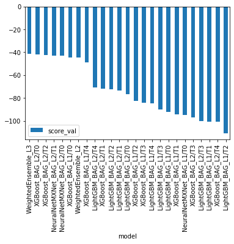

```python
predictor_new_hpo.leaderboard(silent=True).plot(kind='bar', x='model', y='score_val')
```

```python
# Remember to set all negative values to zero
predictor_new_hpo=predictor_new_hpo.predict(test)
predictor_new_hpo[predictor_new_hpo<0]=0
predictor_new_hpo.describe()
```

```
count    6493.000000
mean      187.439209
std       171.685410
min         3.619542
25%        46.313614
50%       144.341507
75%       283.177612
max       866.173462
Name: count, dtype: float64
```

```python
submission_new_hpo = pd.read_csv('sampleSubmission.csv', parse_dates = ['datetime'])

submission_new_hpo.head()
```

|  | datetime | count |
| --- | --- | --- |
| 0 | 2011-01-20 00:00:00 | 0 |
| 1 | 2011-01-20 01:00:00 | 0 |
| 2 | 2011-01-20 02:00:00 | 0 |
| 3 | 2011-01-20 03:00:00 | 0 |
| 4 | 2011-01-20 04:00:00 | 0 |

```python
# Same submitting predictions
submission_new_hpo["count"] = predictor_new_hpo
submission_new_hpo.to_csv("submission_new_hpo.csv", index=False)
```

```python
!kaggle competitions submit -c bike-sharing-demand -f submission_new_hpo.csv -m "new features with hyperparameters"
```

```
Successfully submitted to Bike Sharing Demand
```

```python
!kaggle competitions submissions -c bike-sharing-demand | tail -n +1 | head -n 6
```

```
fileName                     date                 description                        status    publicScore  privateScore
---------------------------  -------------------  ---------------------------------  --------  -----------  ------------
submission_new_hpo.csv       2022-01-12 15:51:03  new features with hyperparameters  complete  0.46413      0.46413
submission_new_features.csv  2022-01-12 15:07:25  new features                       complete  0.48869      0.48869
submission.csv               2022-01-12 14:06:20  first raw submission               complete  1.39644      1.39644
submission_new_hpo.csv       2022-01-11 18:12:01  new features with hyperparameters  complete  0.51059      0.51059
```